2

3

3

2

2

2

Colonized

[figure not shown]

Jamaica

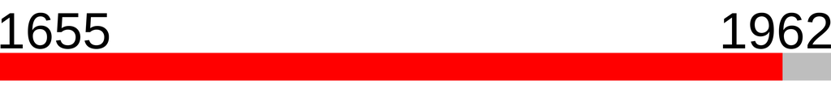

Americas

3

2

3

2

2

2

Colonized

[figure not shown]

India

Asia

4

4

3

4

2

2

Colonized

[figure not shown]

Malawi

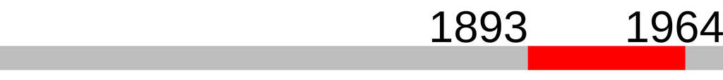

Africa

3

3

3

2

3

3

Colonized

[figure not shown]

Sierra Leone

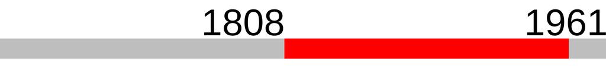

Africa

6

3

3

7

3

3

Colonized

[figure not shown]

United Republic of Tanzania

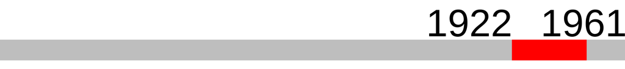

Africa

5

5

3

5

5

4

Colonized

[figure not shown]

Zambia

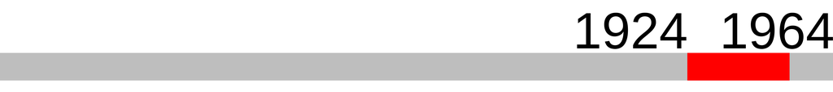

Africa

4

4

4

3

4

3

Colonized

[figure not shown]

Nepal

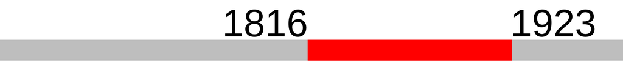

Asia

4

4

4

3

3

3

Colonized

[figure not shown]

Gambia

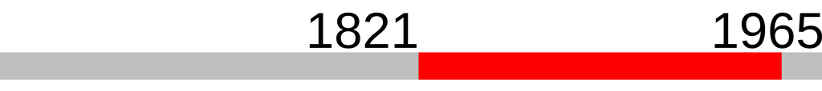

Africa

6

4

4

7

4

4

Colonized

[figure not shown]

Kenya

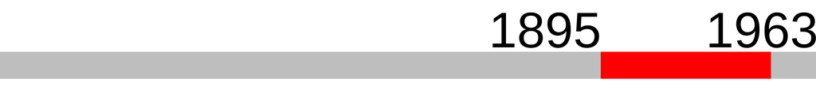

Africa

6

4

4

7

4

4

Colonized

[figure not shown]

Nigeria

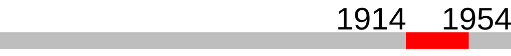

Africa

7

5

4

7

4

4

Colonized

[figure not shown]

Bangladesh

Asia

4

5

4

3

5

4

Colonized

[figure not shown]

Malaysia

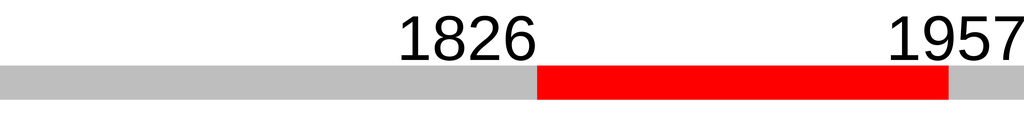

Asia

5

4

4

4

4

4

Colonized

[figure not shown]

Uganda

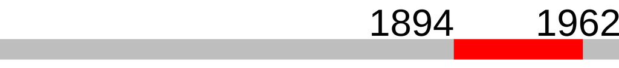

Africa

4

5

4

5

6

5

Colonized

[figure not shown]

Singapore

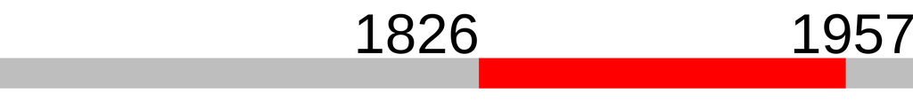

Asia

5

4

4

5

4

5

Colonized

[figure not shown]

Bhutan

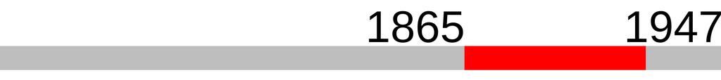

Asia

7

4

5

7

2

3

Colonized

[figure not shown]

Kuwait

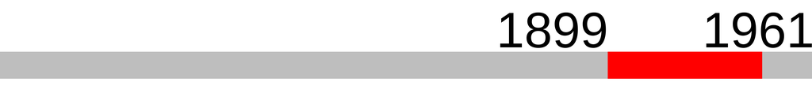

Asia

5

5

5

5

5

4

Colonized

[figure not shown]

Pakistan

Asia

5

5

5

3

5

4

Colonized

[figure not shown]

Jordan

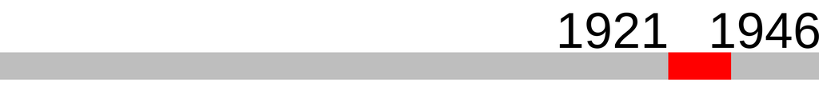

Asia

4

5

5

4

6

5

Colonized

[figure not shown]

Egypt

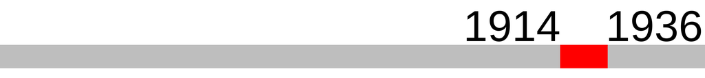

Africa

6

6

5

6

6

6

Colonized

[figure not shown]

Oman

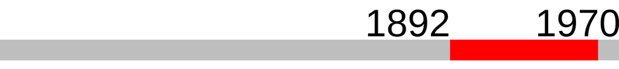

Asia

6

5

5

6

6

6

Colonized

[figure not shown]

Qatar

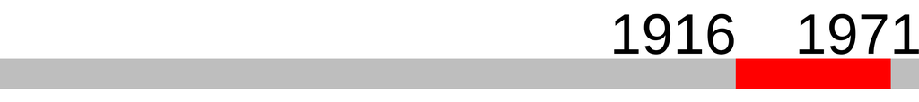

Asia

6

5

5

7

6

6

Colonized

[figure not shown]

United Arab Emirates

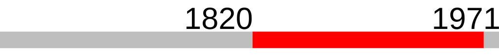

Asia

5

6

5

6

7

6

Colonized

[figure not shown]

Iraq

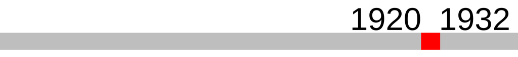

Asia

7

6

6

7

5

5

Colonized

[figure not shown]

Yemen

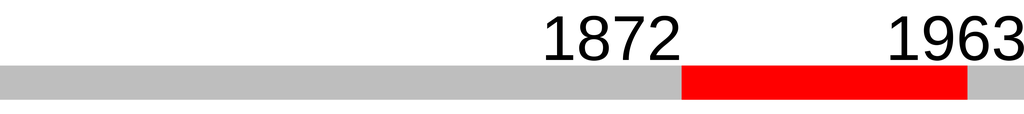

Asia

6

6

6

5

7

5

Colonized

[figure not shown]

Zimbabwe

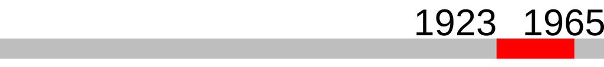

Africa

5

5

6

5

6

6

Colonized

[figure not shown]

Afghanistan

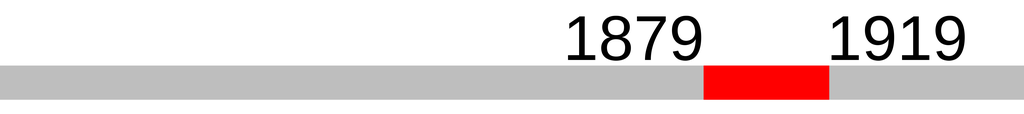

Asia

7

6

6

7

5

6

Colonized

[figure not shown]

Bahrain

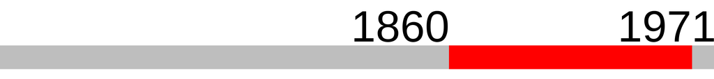

Asia

6

6

6

6

7

7

Colonized

[figure not shown]

Somalia

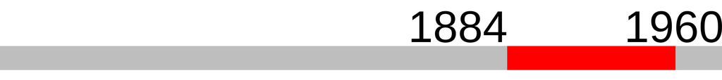

Africa

7

7

7

7

7

7

Colonized

[figure not shown]

Sudan

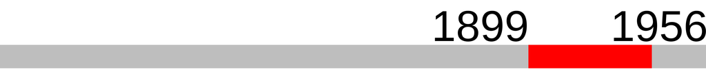

Africa

7

6

7

7

7

7

Colonized

[figure not shown]

Myanmar

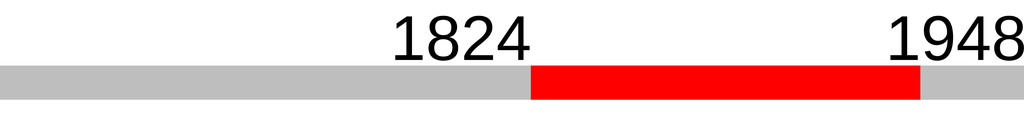

Asia

7

6

7

7

5

7